# Tarea4DEFINITIVO

Veronica Valverde, Karol Aguilar, Juan Carlos Trejos

11/15/2020

Exploración de los datos

```r
wd<-setwd("C:/Users/verov/Documents/UCR/2020/IICiclo/Investigacion_Reproducible/Tarea4/TareaBiologiaIR2")
getwd()
```

```
## [1] "C:/Users/verov/Documents/UCR/2020/IICiclo/Investigacion_Reproducible/Tarea4/TareaBiologiaIR2"
```

```r
dat <- read.csv(file = "TareIR2/Datos_tarea4.csv", header = T, sep = ",", dec = ".")
names(dat)
```

```
## [1] "A"  "P"  "L"  "H1" "H2" "H3" "H4" "H5" "D"
```

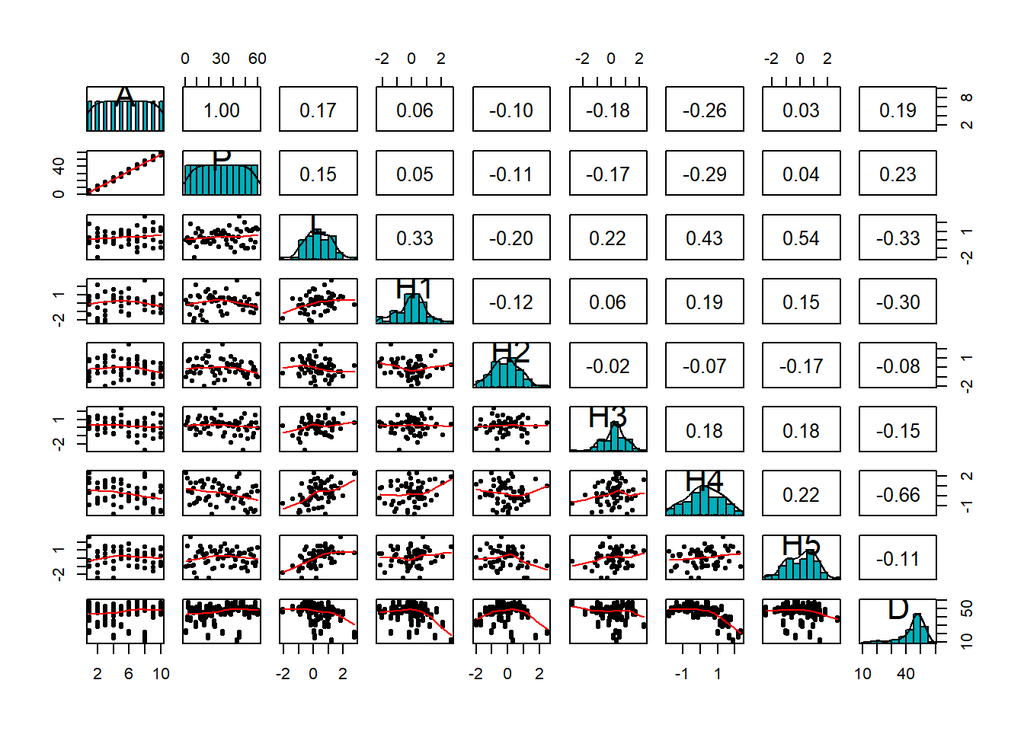

```r
library(psych)
pairs.panels(dat,
             method = "pearson", # correlation method
             hist.col = "#00AFBB",
             density = TRUE,  # show density plots
             ellipses = F # show correlation ellipses
)
```

## Trampa 1

```r
# Trampa 1: categorias de L

datL1 <- subset(dat, L<=0)
datL2 <- subset(dat, L>0)

modL1 <- glm(D ~ H1 + H2 + H3 + H4 + H5, data = datL1, family = "poisson")
summary(modL1)
```

```
##
## Call:
## glm(formula = D ~ H1 + H2 + H3 + H4 + H5, family = "poisson",
##     data = datL1)
##
## Deviance Residuals:
##      Min        1Q    Median        3Q       Max
## -1.92386  -0.41862   0.00416   0.49582   1.66030
##
## Coefficients:
##              Estimate Std. Error z value Pr(>|z|)
## (Intercept)  3.866497   0.012553 308.020  < 2e-16 ***
## H1          -0.009225   0.009029  -1.022   0.3069
## H2           0.012034   0.012977   0.927   0.3538
## H3          -0.002322   0.009772  -0.238   0.8122
## H4          -0.052799   0.012135  -4.351 1.35e-05 ***
## H5           0.024020   0.010442   2.300   0.0214 *
## ---
## Signif. codes:  0 '***' 0.001 '**' 0.01 '*' 0.05 '.' 0.1 ' ' 1
##
## (Dispersion parameter for poisson family taken to be 1)
##
##     Null deviance: 148.59  on 219  degrees of freedom
## Residual deviance: 119.97  on 214  degrees of freedom
## AIC: 1388.2
##
## Number of Fisher Scoring iterations: 4
```

```r
modL2 <- glm(D ~ H1 + H2 + H3 + H4 + H5, data = datL2, family = "poisson")
summary(modL2)
```

```
##
## Call:
## glm(formula = D ~ H1 + H2 + H3 + H4 + H5, family = "poisson",
##     data = datL2)
##
## Deviance Residuals:
##     Min       1Q   Median       3Q      Max
## -3.2962  -0.7587   0.2011   0.9502   2.4779
##
## Coefficients:
##              Estimate Std. Error z value Pr(>|z|)
## (Intercept)  3.810015   0.009719 392.021  < 2e-16 ***
## H1          -0.085321   0.010354  -8.241  < 2e-16 ***
## H2          -0.080187   0.009163  -8.751  < 2e-16 ***
## H3          -0.048467   0.010967  -4.419  9.9e-06 ***
## H4          -0.184389   0.008171 -22.566  < 2e-16 ***
## H5           0.004648   0.008784   0.529    0.597
## ---
## Signif. codes:  0 '***' 0.001 '**' 0.01 '*' 0.05 '.' 0.1 ' ' 1
##
## (Dispersion parameter for poisson family taken to be 1)
##
##     Null deviance: 1307.67  on 379  degrees of freedom
## Residual deviance:  631.94  on 374  degrees of freedom
## AIC: 2736.9
##
## Number of Fisher Scoring iterations: 4
```

## Interpretacion de Trampa 1

La diversidad es afectada por diferentes variables de H(H4 y H5 para latitudes menores o iguales a 0, y de H1 a H4 para latitudes mayores a 0), por lo que la latitud tiene un efecto también en la diversidad alelica.

## Correccion Trampa 1

```r
modL <- glm(D ~ L * H1 + L * H2 + L * H3 + L * H4 + L * H5, data = dat, family = "poisson")
summary(modL)
```

```
##
## Call:
## glm(formula = D ~ L * H1 + L * H2 + L * H3 + L * H4 + L * H5,
##     family = "poisson", data = dat)
##
## Deviance Residuals:
##     Min       1Q   Median       3Q      Max
## -3.1867  -0.5700   0.1470   0.7862   2.1154
##
## Coefficients:
##              Estimate Std. Error z value Pr(>|z|)
## (Intercept)  3.829623   0.007779 492.320  < 2e-16 ***
## L           -0.016470   0.010226  -1.611   0.1072
## H1          -0.049932   0.007079  -7.054 1.74e-12 ***
## H2          -0.040022   0.007784  -5.142 2.72e-07 ***
## H3          -0.009545   0.007412  -1.288   0.1978
## H4          -0.131404   0.007210 -18.225  < 2e-16 ***
## H5           0.011224   0.007118   1.577   0.1148
## L:H1        -0.053870   0.009643  -5.586 2.32e-08 ***
## L:H2        -0.047597   0.010732  -4.435 9.20e-06 ***
## L:H3        -0.038948   0.008397  -4.638 3.51e-06 ***
## L:H4        -0.058464   0.008758  -6.676 2.46e-11 ***
## L:H5         0.014725   0.008345   1.765   0.0776 .
## ---
## Signif. codes:  0 '***' 0.001 '**' 0.01 '*' 0.05 '.' 0.1 ' ' 1
##
## (Dispersion parameter for poisson family taken to be 1)
##
##     Null deviance: 1612.75  on 599  degrees of freedom
## Residual deviance:  751.89  on 588  degrees of freedom
## AIC: 4125.1
##
## Number of Fisher Scoring iterations: 4
```

## Interpretacion corregida de la trampa 1

La latitud debe estar incluida en el modelo, pues influye a las variables H y en consecuencia D. Con este modelo, se observa que la latitud por si sola no tiene un efecto, y al incluirla sólo las variables H1, H2 y H4 tienen un efecto sobre D.

## Trampa 2

```r
mod2 <- glm(D ~ L + H1 + H2 + H3 + H4 + H5, data = dat, family = "poisson")
summary(mod2)
```

```
##
## Call:
## glm(formula = D ~ L + H1 + H2 + H3 + H4 + H5, family = "poisson",
##     data = dat)
##
## Deviance Residuals:
##     Min       1Q   Median       3Q      Max
## -4.2273  -0.7344   0.2375   0.7774   2.5013
##
## Coefficients:
##              Estimate Std. Error z value Pr(>|z|)
## (Intercept)  3.799375   0.006570 578.314  < 2e-16 ***
## L           -0.012830   0.009578  -1.340   0.1804
## H1          -0.046393   0.006825  -6.798 1.06e-11 ***
## H2          -0.040568   0.007358  -5.514 3.52e-08 ***
## H3          -0.007342   0.007059  -1.040   0.2983
## H4          -0.137924   0.006781 -20.338  < 2e-16 ***
## H5           0.012301   0.007029   1.750   0.0801 .
## ---
## Signif. codes:  0 '***' 0.001 '**' 0.01 '*' 0.05 '.' 0.1 ' ' 1
##
## (Dispersion parameter for poisson family taken to be 1)
##
##     Null deviance: 1612.75  on 599  degrees of freedom
## Residual deviance:  940.29  on 593  degrees of freedom
## AIC: 4303.5
##
## Number of Fisher Scoring iterations: 4
```

## Interpretacion de Trampa 2

Las variables latitud, H3 y H5 no explican a D, mientras que H1, H2 y H4 si tienen un efecto. En este caso se estan analizando los 600 datos de la base.

## Correccion Trampa 2

```r
datP <- aggregate(D ~ P + L + H1 + H2 + H3 + H4 + H5, data = dat, FUN = mean)
head(datP)
```

```
##    P     L    H1    H2    H3    H4    H5    D
## 1 20  0.19  0.58  1.23 -0.70 -0.09 -2.46 44.3
## 2 10 -0.78 -0.59  1.03 -0.26 -0.55 -2.44 48.4
## 3  8 -2.08 -1.83 -0.62  0.27 -0.76 -1.79 47.3
## 4 52 -0.99 -0.29 -0.69 -1.35 -1.69 -1.56 47.4
## 5 23  0.20  0.67 -0.47  0.43  0.90 -1.32 47.8
## 6 24 -0.17  0.45 -1.71  1.01  1.46 -1.22 31.7
```

```r
modP <- glm(D ~ L + H1 + H2 + H3 + H4 + H5, data = datP, family = "poisson")
summary(modP)
```

```
##
## Call:
## glm(formula = D ~ L + H1 + H2 + H3 + H4 + H5, family = "poisson",
##     data = datP)
##
## Deviance Residuals:
##     Min       1Q   Median       3Q      Max
## -3.9470  -0.7246   0.2425   0.7720   2.0340
##
## Coefficients:
##              Estimate Std. Error z value Pr(>|z|)
## (Intercept)  3.799375   0.020775 182.879  < 2e-16 ***
## L           -0.012830   0.030287  -0.424   0.6718
## H1          -0.046393   0.021583  -2.150   0.0316 *
## H2          -0.040568   0.023268  -1.744   0.0812 .
## H3          -0.007342   0.022324  -0.329   0.7422
## H4          -0.137924   0.021445  -6.432 1.26e-10 ***
## H5           0.012301   0.022228   0.553   0.5800
## ---
## Signif. codes:  0 '***' 0.001 '**' 0.01 '*' 0.05 '.' 0.1 ' ' 1
##
## (Dispersion parameter for poisson family taken to be 1)
##
##     Null deviance: 158.504  on 59  degrees of freedom
## Residual deviance:  91.258  on 53  degrees of freedom
## AIC: Inf
##
## Number of Fisher Scoring iterations: 4
```

## Interpretacion de Trampa 2 corregida

Solo la variable H4 tiene un efecto importante (H1 tiene un efecto pero cuestionable) sobre D, esto al tomar solo un valor de D por poblacion (se tomo el promedio porque no se supo como hacerlo mejor). Indica que cuando se tomaban todos los valores (600) habia una pseudoreplicacion, es decir una Inflacion de N.

## Trampa 3

```r
mod4a <- glm(D ~ L + H1, data = dat, family = "poisson")
summary(mod4a)
```

```
##
## Call:
## glm(formula = D ~ L + H1, family = "poisson", data = dat)
##
## Deviance Residuals:
##     Min       1Q   Median       3Q      Max
## -5.1365  -0.5640   0.3374   0.9637   2.3184
##
## Coefficients:
##              Estimate Std. Error z value Pr(>|z|)
## (Intercept)  3.795064   0.006453 588.111  < 2e-16 ***
## L           -0.066689   0.007369  -9.050  < 2e-16 ***
## H1          -0.048808   0.006537  -7.467 8.23e-14 ***
## ---
## Signif. codes:  0 '***' 0.001 '**' 0.01 '*' 0.05 '.' 0.1 ' ' 1
##
## (Dispersion parameter for poisson family taken to be 1)
##
##     Null deviance: 1612.8  on 599  degrees of freedom
## Residual deviance: 1405.1  on 597  degrees of freedom
## AIC: 4760.2
##
## Number of Fisher Scoring iterations: 4
```

```r
mod4b <- glm(D ~ L + H2, data = dat, family = "poisson")
summary(mod4b)
```

```
##
## Call:
## glm(formula = D ~ L + H2, family = "poisson", data = dat)
##
## Deviance Residuals:
##     Min       1Q   Median       3Q      Max
## -5.6038  -0.5256   0.3715   0.9557   2.3379
##
## Coefficients:
##              Estimate Std. Error z value Pr(>|z|)
## (Intercept)  3.799507   0.006392 594.436  < 2e-16 ***
## L           -0.093260   0.007066 -13.199  < 2e-16 ***
## H2          -0.040134   0.007135  -5.625 1.86e-08 ***
## ---
## Signif. codes:  0 '***' 0.001 '**' 0.01 '*' 0.05 '.' 0.1 ' ' 1
##
## (Dispersion parameter for poisson family taken to be 1)
##
##     Null deviance: 1612.8  on 599  degrees of freedom
## Residual deviance: 1429.1  on 597  degrees of freedom
## AIC: 4784.3
##
## Number of Fisher Scoring iterations: 4
```

```r
mod4c <- glm(D ~ L + H3, data = dat, family = "poisson")
summary(mod4c)
```

```
##
## Call:
## glm(formula = D ~ L + H3, family = "poisson", data = dat)
##
## Deviance Residuals:
##     Min       1Q   Median       3Q      Max
## -5.7302  -0.5687   0.4344   0.9624   2.1658
##
## Coefficients:
##              Estimate Std. Error z value Pr(>|z|)
## (Intercept)  3.803620   0.006410 593.364   <2e-16 ***
## L           -0.080879   0.007127 -11.348   <2e-16 ***
## H3          -0.020475   0.007034  -2.911   0.0036 **
## ---
## Signif. codes:  0 '***' 0.001 '**' 0.01 '*' 0.05 '.' 0.1 ' ' 1
##
## (Dispersion parameter for poisson family taken to be 1)
##
##     Null deviance: 1612.8  on 599  degrees of freedom
## Residual deviance: 1452.4  on 597  degrees of freedom
## AIC: 4807.5
##
## Number of Fisher Scoring iterations: 4
```

```r
mod4d <- glm(D ~ L + H4, data = dat, family = "poisson")
summary(mod4d)
```

```
##
## Call:
## glm(formula = D ~ L + H4, family = "poisson", data = dat)
##
## Deviance Residuals:
##     Min       1Q   Median       3Q      Max
## -4.7965  -0.6995   0.2710   0.7901   2.2562
##
## Coefficients:
##              Estimate Std. Error z value Pr(>|z|)
## (Intercept)  3.805755   0.006378 596.740   <2e-16 ***
## L           -0.015249   0.007694  -1.982   0.0475 *
## H4          -0.141577   0.006749 -20.978   <2e-16 ***
## ---
## Signif. codes:  0 '***' 0.001 '**' 0.01 '*' 0.05 '.' 0.1 ' ' 1
##
## (Dispersion parameter for poisson family taken to be 1)
##
##     Null deviance: 1612.8  on 599  degrees of freedom
## Residual deviance: 1019.7  on 597  degrees of freedom
## AIC: 4374.9
##
## Number of Fisher Scoring iterations: 4
```

```r
mod4e <- glm(D ~ L + H5, data = dat, family = "poisson")
summary(mod4e)
```

```
##
## Call:
## glm(formula = D ~ L + H5, family = "poisson", data = dat)
##
## Deviance Residuals:
##     Min       1Q   Median       3Q      Max
## -5.8131  -0.5757   0.4018   0.9672   2.3401
##
## Coefficients:
##              Estimate Std. Error z value Pr(>|z|)
## (Intercept)  3.803705   0.006411 593.277  < 2e-16 ***
## L           -0.099510   0.008344 -11.926  < 2e-16 ***
## H5           0.021009   0.006937   3.028  0.00246 **
## ---
## Signif. codes:  0 '***' 0.001 '**' 0.01 '*' 0.05 '.' 0.1 ' ' 1
##
## (Dispersion parameter for poisson family taken to be 1)
##
##     Null deviance: 1612.8  on 599  degrees of freedom
## Residual deviance: 1451.6  on 597  degrees of freedom
## AIC: 4806.8
##
## Number of Fisher Scoring iterations: 4
```

## Interpretacion Trampa 3

Todas las variables H tienen un efecto sobre la diversidad alelica D, si las evaluamos de manera independiente.

## Correccion Trampa 3

```r
mod4 <- glm(D ~ L + H1 + H2 + H3 + H4 + H5, data = dat, family = "poisson")
summary(mod4)
```

```
##
## Call:
## glm(formula = D ~ L + H1 + H2 + H3 + H4 + H5, family = "poisson",
##     data = dat)
##
## Deviance Residuals:
##     Min       1Q   Median       3Q      Max
## -4.2273  -0.7344   0.2375   0.7774   2.5013
##
## Coefficients:
##              Estimate Std. Error z value Pr(>|z|)
## (Intercept)  3.799375   0.006570 578.314  < 2e-16 ***
## L           -0.012830   0.009578  -1.340   0.1804
## H1          -0.046393   0.006825  -6.798 1.06e-11 ***
## H2          -0.040568   0.007358  -5.514 3.52e-08 ***
## H3          -0.007342   0.007059  -1.040   0.2983
## H4          -0.137924   0.006781 -20.338  < 2e-16 ***
## H5           0.012301   0.007029   1.750   0.0801 .
## ---
## Signif. codes:  0 '***' 0.001 '**' 0.01 '*' 0.05 '.' 0.1 ' ' 1
##
## (Dispersion parameter for poisson family taken to be 1)
##
##     Null deviance: 1612.75  on 599  degrees of freedom
## Residual deviance:  940.29  on 593  degrees of freedom
## AIC: 4303.5
##
## Number of Fisher Scoring iterations: 4
```

## Interpretacion de Trampa 3 corregida

Al hacer un modelo con todas las H se nota que H3 y H5 no afectan a D. Esto se corrige aplicando un modelo incluyendo todas las variables H a la vez. En este caso se observa que solo las variables H1, H2 y H4 tienen un efecto sobre la diversidad alelica.